# Introduction to R packages

## This Lecture

1. What is an `R` package, and why should you write your own?
2. A quick demo using an application of Monte Carlo methods.

Where to find these slides: github.com/jcockayne/math3092_2021.

Further reading: “R packages” by Hadley Wickham and Jenny Bryan, available at [r-pkgs.org](https://r-pkgs.org/).

## `R` packages

`R` packages are collections of code, documentation and data written by other `R` users.

The main source of `R` packages is CRAN (the Comprehensive R Archive Network).

As of October 2021, more than 18000 packages are available on CRAN!

One of the main advantages of `R` is the fact that so many add on packages are available.

## Using `R` packages

If a package is available on CRAN, you can install and use it easily:

```r
install.packages("fortunes")
```

```r
library(fortunes)
fortune("statistics")
```

```
##
## Robin Hankin: I'd say that without a tool like R you cannot learn statistics.
## David Whiting: I believe Fisher and a few others managed to get by without it.
## Peter Dalgaard: But think how far they could have got with R!
##    -- Robin Hankin, David Whiting, and Peter Dalgaard (on teaching/learning
##       statistics with R)
##       R-help (December 2004)
```

## `R` packages on Github

There are many other packages which are stored on Github: it is also easy to install and use these, although there are no quality checks enforced for packages on Github.

```r
# install.packages("devtools")
devtools::install_github("Gibbsdavidl/CatterPlots")
```

```r
library(CatterPlots)
```

```r
n <- 50
x <- runif(n)
y <- x + rnorm(n, sd = 0.5)

catplot(x, y)
```

## `R` packages on Github

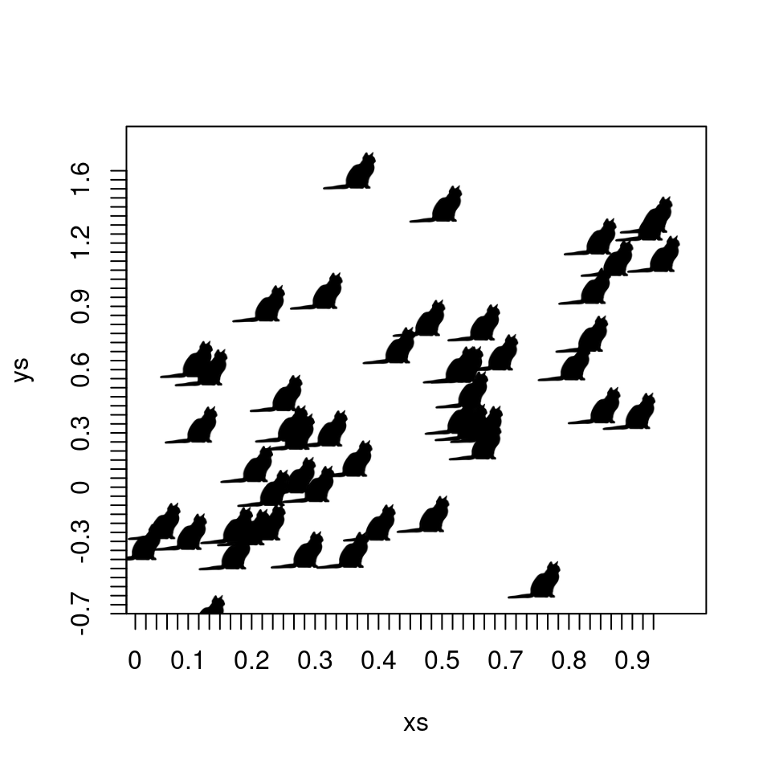

## A birthday problem

Suppose that there are 30 people in a room. What is the chance that at least two of them share the same birthday?

## A Monte Carlo approach

We can simulate

```r
birthdays <- sample(1:365, 30, replace = TRUE)
table(birthdays)
```

```
## birthdays
##   9  12  13  14  33  44  53  55  85 110 112 163 179 193 205 256 259 275 294 300
##   1   1   1   1   1   1   1   1   1   1   1   1   1   1   1   2   1   1   2   1
## 301 306 318 344 345 349 354 364
##   1   1   1   1   1   1   1   1
```

```r
any(table(birthdays) > 1)
```

```
## [1] TRUE
```

## A Monte Carlo approach

Now repeat that simulation lots of times

```r
n_sim <- 10000

matches <- replicate(n_sim, {
    birthdays <- sample(1:365, 30, replace = TRUE)
    table(birthdays)
    any(table(birthdays) > 1)
})

mean(matches)
```

```
## [1] 0.7035
```

## A(nother) birthday problem

Suppose that there are 23 people in a room. What is the chance that at least two of them share the same birthday?

## Copy, paste and edit

Edit our code from before:

```r
n_sim <- 100000

matches <- replicate(n_sim, {
    birthdays <- sample(1:365, 23, replace = TRUE)
    table(birthdays)
    any(table(birthdays) > 1)
})

mean(matches)
```

```
## [1] 0.50601
```

## Or… put it in a function

```r
approx_birthday_match_prob <- function(n_people, n_sim = 100000) {
    matches <- replicate(n_sim, {
        birthdays <- sample(1:365, n_people, replace = TRUE)
        table(birthdays)
        any(table(birthdays) > 1)
    })
    mean(matches)
}

approx_birthday_match_prob(30)
```

```
## [1] 0.70724
```

```r
approx_birthday_match_prob(23)
```

```
## [1] 0.50661
```

## Exact calculation

```r
birthday_match_prob <- function(n_people) {
    if(n_people >= 365) {
        prob_no_match <- 0
    } else {
        components <- 1 - ((1:n_people) - 1) / 365
        prob_no_match <- prod(components)
    }
    1 - prob_no_match
}

birthday_match_prob(30)
```

```
## [1] 0.7063162
```

```r
birthday_match_prob(23)
```

```
## [1] 0.5072972
```

## Put it in a package

Let’s make an `R` package, called `birthdayproblem` to share our `R` code with others.

The `devtools` package contains lots of helpful tools for creating your own `R` package

```r
library(devtools)
```

To get started, we use

```r
create_package("birthdayproblem")
```

This gives us the basic structure of a package, without any `R` code yet.

## Next steps

1. [Set up with git](https://r-pkgs.org/git.html): `use_git()` (then commit changes after each step).
2. [Add our `R` code](https://r-pkgs.org/r.html) in the `R` directory. Load the code with `load_all()` and try it!
3. [Write some documentation](https://r-pkgs.org/man.html) and examples. Convert into the correct format with `document()`, then take a look at the new help files with `help()`.
4. [Write the `DESCRIPTION` file](https://r-pkgs.org/description.html), which contains some basic information about your package.
5. [Create a Github repository for your package](https://r-pkgs.org/git.html), and connect to your local version
6. [Write a README](https://r-pkgs.org/release.html#readme-rmd) (in R markdown format) with `use_readme_rmd()`.

## The `birthdayproblem` package

You can see the package at https://github.com/heogden/birthdayproblem

This Github site includes both:

1. a simple website for the package, with basic installation and usage instructions
2. all the code for the package, so that others can modify it.

## Conclusion

Writing an `R` package is a great way to make your work easy to use by other people (or even your future self).

There are many other topics we have not covered here, which are important if you are writing a more complex package.

Take a look at the book “R packages” by Hadley Wickham and Jenny Bryan, available at [r-pkgs.org](https://r-pkgs.org/).

The best way to learn how to write an `R` package is to try it!